# Mia_Dust_Fungi_CCAenvfit

Nat Pombubpa

Updated on October 29, 2018

### STEP1: Load all necessary packages for analysis

More information about Phyloseq can be found at the following link: [Phyloseq](https://joey711.github.io/phyloseq/) If you get error in this step, you probably need to install any packages which causes error.

```r
library(ape)
library(vegan)
library(plyr)
library(dplyr)
library(scales)
library(grid)
library(reshape2)
library(phyloseq)
library(magrittr)
library(ggplot2)
library(ggpubr)
library(data.table)
```

### STEP2: Import Mapping file (metadate file)

1.Check mapping file before import to R, R will automatically change sample name that starts with number or contain “-” in sample name.

2.First column of first row should not start with #, R will not read the first row that starts with ‘#’

3. You can choose which samples to include in analysis by indicating specific group in the column

```r
meta = read.table("SierraMapIsoF.csv",
                  header=TRUE,row.names=1,
                  sep=",",stringsAsFactors=FALSE)
```

### STEP3: Check if your metadata file has been import successfully and correctly

The output will show a table of your metadata file (mapping file).

*If you do not have header, you might start your first row with #

```r
head(meta)
```

```
##       BarcodeSequence LinkerPrimerSequence Year  NdEp       Sr  Month
## AJ414              NA                   NA  one -3.97 0.708101 August
## AP114              NA                   NA  one -4.30 0.708349 August
## AS114              NA                   NA  one -4.57 0.709982 August
## AT414              NA                   NA  one -3.95 0.708165 August
## JJ114              NA                   NA  one -3.98 0.708293   July
## JJ415              NA                   NA  two -4.10 0.707771   July
##       SiteCode RepNum SiteRep       Site Elevation DateCode DescName
## AJ414        J      4      J4       SJER       400        B    AJ414
## AP114        P      1      P1 PROVIDENCE      2000        B    AP114
## AS114        S      1      S1  SHORTHAIR      2700        B    AS114
## AT414        T      4      T4   SOAPROOT      1100        B    AT414
## JJ114        J      1      J1       SJER       400        A    JJ114
## JJ415        J      4      J4       SJER       400        A    JJ415
##       Description
## AJ414      BAJ414
## AP114      BAP114
## AS114      BAS114
## AT414      BAT414
## JJ114      AJJ114
## JJ415      AJJ415
```

### STEP4: Construct sample_data-class using imported metadata

```r
sampleData <- sample_data(meta)
```

### STEP5: Import OTU table

```r
otus <- read.table("DustFungi.otu_table.txt",
                   header=T,sep="\t",row.names = 1)
otumat <- as(as.matrix(otus), "matrix")
OTU = otu_table(otumat, taxa_are_rows = TRUE)
```

```r
head(otus)
```

```
##         AJ414 AP114 AS114 AT414 JJ114 JJ415 JJ515 JP315 JP414 JP515 JS115
## OTU1     9461  5607 11584  1649    17    46    92   769   787 10086  8432
## OTU10    8549     4   174    43    93    70    34    60     4   124    67
## OTU100     10     6     1   126     9    21    34     2     3     0     1
## OTU1000     0     0     0     1     0     0     0     1     0     0     0
## OTU1001     0     0     0     0     0    10     0     0     0     0     0
## OTU1002   108  1114    13   917  1004   927   864   440   601   163   152
##         JS415 JT115 JT314 JT415 OJ415 OJ514 OJ515 OJ615 OP315 OP515 OP614
## OTU1     6952    58  1258   182    59    76   136   202  2765 15177  5679
## OTU10     198   114   174   522    25    46    19    15   303   343     0
## OTU100      2   124   133    39     2    14     4     9     0     0    12
## OTU1000     0     0     0     0     0     0     0     0     0     0     1
## OTU1001     0     0     0     0     2     0     0     0     0     0     0
## OTU1002   111   338  1053    51  1492  2167  1571   377    44   181    26
##         OP615 OS115 OS214 OS415 OS615 OT115 OT414 OT415 OT515
## OTU1     2264 12199  4225  7247 27541  6461 34777  4072  3570
## OTU10     140   100    91   287    20   260    96   733  1232
## OTU100      0     1    25     3     0    19   359     8     9
## OTU1000     0     0     0     1     0     4     0     0     0
## OTU1001     0     0     0     0     0     0     0     0     0
## OTU1002   255   130    34   192     2   847   862   165   110
```

### STEP6: Import taxonomy table

Taxonmy table generated from AMPtk need to be rearranged using following script.

“perl rdp_taxonmy2mat.pl<Input_taxonmy.txt>Output_taxonomy.txt”

rdp_taxonomy2mat.pl was created by Professor Jason E. Stajich

```r
taxmat <- read.table("DustFungi.taxonomy.fix.txt",
                     header=T,sep="\t",row.names=1)
taxmat <- as(as.matrix(taxmat),"matrix")
TAX = tax_table(taxmat)
```

### STEP7: Construct Phyloseq object

To construct phyloseq object, otu table, taxonomy table, and sampleData are required. Phylogenetic tree can be included, but it is not necessary for constructing phyloseq object. Construct Phyloseq object called “Physeq”

```r
physeq = phyloseq(OTU,TAX,sampleData)
```

### STEP8: Check phyloseq object

This should indicate that your physeq is a “phyloseq-class experiment-level object”

```r
physeq
```

```
## phyloseq-class experiment-level object
## otu_table()   OTU Table:         [ 2180 taxa and 31 samples ]
## sample_data() Sample Data:       [ 31 samples by 14 sample variables ]
## tax_table()   Taxonomy Table:    [ 2180 taxa by 7 taxonomic ranks ]
```

### STEP9: Remove singletons

Remove any OTUs that present only one time.

```r
physeq.prune = prune_taxa(taxa_sums(physeq) > 1, physeq)
```

```r
physeq.prune
```

```
## phyloseq-class experiment-level object
## otu_table()   OTU Table:         [ 2180 taxa and 31 samples ]
## sample_data() Sample Data:       [ 31 samples by 14 sample variables ]
## tax_table()   Taxonomy Table:    [ 2180 taxa by 7 taxonomic ranks ]
```

## STEP10: Plot read counts to check dataset

Check read counts: any samples that have very low reads should be removed. [Ref](http://evomics.org/wp-content/uploads/2016/01/phyloseq-Lab-01-Answers.html)

```r
readcount = data.table(as(sample_data(physeq.prune), "data.frame"),
                 TotalReads = sample_sums(physeq.prune),
                 keep.rownames = TRUE)
setnames(readcount, "rn", "SampleID")
SeqDepth = ggplot(readcount, aes(TotalReads)) + geom_histogram() + ggtitle("Sequencing Depth")
```

```r
readcount = readcount[order(readcount$TotalReads), c("SampleID", "TotalReads")]
```

```r
head(readcount)
```

```
##    SampleID TotalReads
## 1:    JT415       7325
## 2:    JP315      13122
## 3:    OJ515      13880
## 4:    OJ415      14271
## 5:    OP615      14402
## 6:    JS415      14866
```

### STEP11:Rarefy OTUs to a minimum number of reads (OPTIONAL)

Rarefy OTUs (remove any samples that has very low number of reads)

```r
set.seed(711)
physeq.prune.rarefy = rarefy_even_depth(physeq.prune, sample.size = 7325, replace = FALSE, trimOTUs = TRUE)
```

```
## You set `rngseed` to FALSE. Make sure you've set & recorded
##  the random seed of your session for reproducibility.
## See `?set.seed`
```

```
## ...
```

```
## 274OTUs were removed because they are no longer
## present in any sample after random subsampling
```

```
## ...
```

```r
physeq.prune.rarefy
```

```
## phyloseq-class experiment-level object
## otu_table()   OTU Table:         [ 1906 taxa and 31 samples ]
## sample_data() Sample Data:       [ 31 samples by 14 sample variables ]
## tax_table()   Taxonomy Table:    [ 1906 taxa by 7 taxonomic ranks ]
```

You have successfully imported data to R and completely generate phyloseq object as “physeq.prune.rarefy”.

### STEP12: Calculating distance matrix (bray curtis)

```r
ps.dist = phyloseq::distance(physeq.prune.rarefy, "bray")
```

### STEP12.1: PERMANOVA on environmental data

```r
colnames(meta)
```

```
##  [1] "BarcodeSequence"      "LinkerPrimerSequence" "Year"
##  [4] "NdEp"                 "Sr"                   "Month"
##  [7] "SiteCode"             "RepNum"               "SiteRep"
## [10] "Site"                 "Elevation"            "DateCode"
## [13] "DescName"             "Description"
```

```r
set.seed(1)
adonis(ps.dist ~Sr+NdEp+Elevation, as(sample_data(physeq.prune.rarefy),"data.frame"))
```

```
##
## Call:
## adonis(formula = ps.dist ~ Sr + NdEp + Elevation, data = as(sample_data(physeq.prune.rarefy),      "data.frame"))
##
## Permutation: free
## Number of permutations: 999
##
## Terms added sequentially (first to last)
##
##           Df SumsOfSqs MeanSqs F.Model      R2 Pr(>F)
## Sr         1    1.0085 1.00854  4.8709 0.13280  0.001 ***
## NdEp       1    0.3384 0.33839  1.6343 0.04456  0.095 .
## Elevation  1    0.6568 0.65677  3.1719 0.08648  0.007 **
## Residuals 27    5.5905 0.20706         0.73615
## Total     30    7.5942                 1.00000
## ---
## Signif. codes:  0 '***' 0.001 '**' 0.01 '*' 0.05 '.' 0.1 ' ' 1
```

Using “formaula” to indicate environmental factors for distance/ordinate calculation.

```r
physeq.prune.rarefy.ps.cca <- ordinate(physeq.prune.rarefy, "CCA",
                                       formula = ~Sr+NdEp+Elevation)
```

### STEP13: Plot ordination

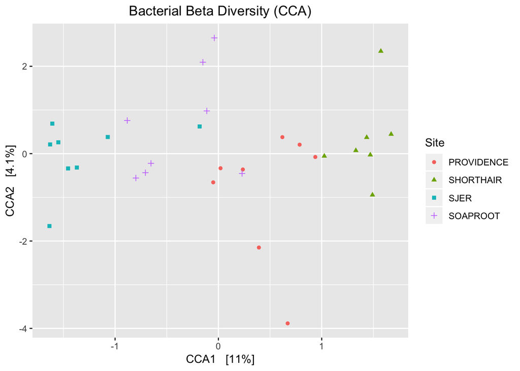

```r
plot_ordination(physeq.prune.rarefy, physeq.prune.rarefy.ps.cca, type = "samples",
                color = "Site", shape = "Site") + ggtitle("Bacterial Beta Diversity (CCA)") + theme(plot.title = element_text(hjust = 0.5))
```

add ordination plot to a variable “pcca”

```r
pcca = plot_ordination(physeq.prune.rarefy, physeq.prune.rarefy.ps.cca, type = "samples",
                       color = "Site", shape = "Site")
```

### STEP14: Get environmental distance from CCA to arrows

```r
arrowdist <- vegan::scores(physeq.prune.rarefy.ps.cca, display = c("bp"))
```

Check data for arrow distance, you should see your environmental factor with distances (CCA1 and CCA2)

```r
head(arrowdist)
```

```
##                 CCA1        CCA2
## Sr         0.8197539  0.55970395
## NdEp      -0.6178102 -0.03726884
## Elevation  0.9952520 -0.09544539
```

### STEP15: Add arrow distance to data frame

```r
arrowdf <- data.frame(labels = rownames(arrowdist), arrowdist)
```

Check data frame for arrow distance

```r
head(arrowdf)
```

```
##              labels       CCA1        CCA2
## Sr               Sr  0.8197539  0.55970395
## NdEp           NdEp -0.6178102 -0.03726884
## Elevation Elevation  0.9952520 -0.09544539
```

### STEP16: Define arrow starting point and labels

Defining arrow starting point and coordinates for fitting into CCA plot.

```r
arrow_map = aes(xend = CCA1, yend = CCA2, x = 0, y = 0, shape = NULL, color = NULL, label = labels)
label_map = aes(x = 1.1 * CCA1, y = 1.1 * CCA2, shape = NULL, color = NULL, label = labels)
```

### STEP17: Add environemntal arrow data to plot

```r
arrowhead = arrow(length = unit(0.05, "npc"))
pcca.envfit = pcca + geom_segment(arrow_map, size = 0.8, data = arrowdf, color = "gray",
    arrow = arrowhead) + geom_text(label_map, size = 3, data = arrowdf) +
  ggtitle("Bacterial Beta Diversity (CCA)") + theme(plot.title = element_text(hjust = 0.5))
```

### STEP18: CCA plot with environmental fit

Now, the CCA plot should inculde environmental arrows.

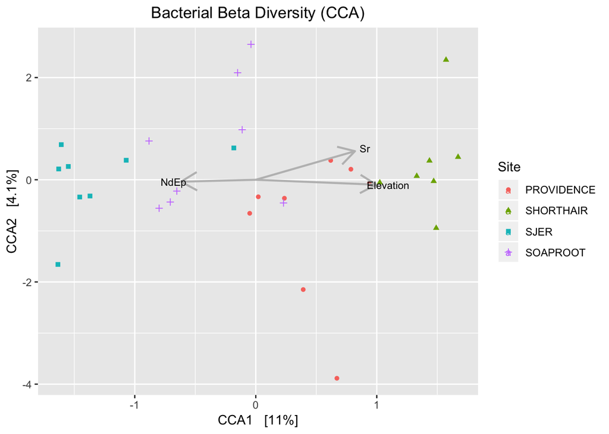

```r
pcca.envfit
```

### Testing with Ordistep

```r
metacca = meta[c(4,5,11)]
```

```r
head(metacca)
```

```
##        NdEp       Sr Elevation
## AJ414 -3.97 0.708101       400
## AP114 -4.30 0.708349      2000
## AS114 -4.57 0.709982      2700
## AT414 -3.95 0.708165      1100
## JJ114 -3.98 0.708293       400
## JJ415 -4.10 0.707771       400
```

```r
TOTU = t(OTU)
```

```r
ps.cca = cca(TOTU ~ 1, metacca)
```

```r
ps.cca1 = cca(TOTU ~ ., metacca)
```

```r
ordistep(ps.cca, scope=formula(ps.cca1), perm.max=999)
```

```
##
## Start: TOTU ~ 1
##
##             Df    AIC      F Pr(>F)
## + Elevation  1 361.11 3.2056  0.005 **
## + Sr         1 361.73 2.5644  0.005 **
## + NdEp       1 362.43 1.8625  0.005 **
## ---
## Signif. codes:  0 '***' 0.001 '**' 0.01 '*' 0.05 '.' 0.1 ' ' 1
##
## Step: TOTU ~ Elevation
##
##             Df    AIC      F Pr(>F)
## - Elevation  1 362.36 3.2056  0.005 **
## ---
## Signif. codes:  0 '***' 0.001 '**' 0.01 '*' 0.05 '.' 0.1 ' ' 1
##
##        Df    AIC      F Pr(>F)
## + Sr    1 361.16 1.8141  0.010 **
## + NdEp  1 361.21 1.7612  0.025 *
## ---
## Signif. codes:  0 '***' 0.001 '**' 0.01 '*' 0.05 '.' 0.1 ' ' 1
##
## Step: TOTU ~ Elevation + Sr
##
##             Df    AIC      F Pr(>F)
## - Sr         1 361.11 1.8141  0.015 *
## - Elevation  1 361.73 2.4197  0.005 **
## ---
## Signif. codes:  0 '***' 0.001 '**' 0.01 '*' 0.05 '.' 0.1 ' ' 1
##
##        Df    AIC      F Pr(>F)
## + NdEp  1 361.16 1.7992  0.015 *
## ---
## Signif. codes:  0 '***' 0.001 '**' 0.01 '*' 0.05 '.' 0.1 ' ' 1
##
## Step: TOTU ~ Elevation + Sr + NdEp
##
##             Df    AIC      F Pr(>F)
## - Sr         1 361.21 1.8505  0.015 *
## - NdEp       1 361.16 1.7992  0.010 **
## - Elevation  1 361.87 2.4657  0.005 **
## ---
## Signif. codes:  0 '***' 0.001 '**' 0.01 '*' 0.05 '.' 0.1 ' ' 1
```

```
## Call: cca(formula = TOTU ~ Elevation + Sr + NdEp, data = metacca)
##
##               Inertia Proportion Rank
## Total          3.7574     1.0000
## Constrained    0.7784     0.2072    3
## Unconstrained  2.9791     0.7928   27
## Inertia is scaled Chi-square
##
## Eigenvalues for constrained axes:
##   CCA1   CCA2   CCA3
## 0.3832 0.2094 0.1858
##
## Eigenvalues for unconstrained axes:
##    CA1    CA2    CA3    CA4    CA5    CA6    CA7    CA8
## 0.4301 0.3842 0.3436 0.2890 0.2479 0.2058 0.1697 0.1540
## (Showed only 8 of all 27 unconstrained eigenvalues)
```